# Multi-level LCA Demo

Adam Garber

2/7/2020

## ______________________________________________

## ______________________________________________

### This demonstration of Multi-level Latent Class Analysis (MLCA) replicates the 7 models -resented in Henry & Muthén (2010) using a new data example.

#### **Note:** All models are estimated in Mplus via the interface R package {MplusAutomation}.

## ______________________________________________

#### References

Henry, K. L., & Muthén, B. (2010). Multilevel latent class analysis: An application of adolescent smoking typologies with individual and contextual predictors. Structural Equation Modeling, 17(2), 193-215.

Hallquist, M. N., & Wiley, J. F. (2018). MplusAutomation: An R Package for Facilitating Large-Scale Latent Variable Analyses in Mplus. Structural equation modeling: a multidisciplinary journal, 25(4), 621-638.

Muthén, L.K. and Muthén, B.O. (1998-2017). Mplus User’s Guide. Eighth Edition. Los Angeles, CA: Muthén & Muthén

#### loading packages…

```r
library(tidyverse)
library(haven)
library(MplusAutomation)
library(rhdf5)
library(here)
library(glue)
library(stargazer)
library(kableExtra)
library(janitor)
library(semPlot)
library(reshape2)
library(cowplot)
library(magick)
```

#### read spss >>> write csv >>> read csv

```r
data_spss <- read_spss(here("data", "teacher_discip_strat_data.sav")) %>%
  clean_names()

# write a CSV datafile (to remove labels)
write_csv(data_spss, here("data", "teach_discip_data.csv"))
```

#### read the unlabeled data back into R

```r
mlca_data <- read_csv(here("data", "teach_discip_data.csv"),
                      na = c("9999"))
```

#### view data with labels and response-levels

```r
sjPlot::view_df(data_spss)
```

#### prepare data for MplusAutomation

```r
mlca_mplus <- mlca_data %>%
  select(-id, -districtname, -schoolname) # remove columns with strings
```

#### shorten names to be < 8 characters

```r
names(mlca_mplus) <-  str_remove(names(mlca_mplus), pattern = "itive")

mlca_mplus <- mlca_mplus %>%
  rename(pop =  population,  # Bullying is a big problem in this school
         distcode = districtcode,
         schlcode = schoolcode,
         postcode = positioncode)
```

#### make summary descriptives table

```r
lca_summary <- mlca_mplus %>%
  select(53:67)

stargazer(as.data.frame(lca_summary), type="text", header = FALSE, digits=1)
```

```
##
## =======================================================
## Statistic   N   Mean St. Dev. Min Pctl(25) Pctl(75) Max
## -------------------------------------------------------
## pun_1     5,087 1.8    0.5    1.0   2.0      2.0    4.0
## pos_1     5,087 3.2    0.6    1.0   3.0      4.0    4.0
## sel_1     5,087 3.1    0.6    1.0   3.0      3.0    4.0
## pun_2     5,087 2.2    0.7    1.0   2.0      3.0    4.0
## pos_2     5,087 3.0    0.6    1.0   3.0      3.0    4.0
## sel_2     5,087 3.0    0.6    1.0   3.0      3.0    4.0
## pun_3     5,087 1.9    0.6    1.0   2.0      2.0    4.0
## pos_3     5,087 3.2    0.5    1.0   3.0      4.0    4.0
## sel_3     5,087 3.1    0.6    1.0   3.0      3.0    4.0
## pun_4     5,087 2.0    0.7    1.0   2.0      2.0    4.0
## pos_4     5,087 3.0    0.7    1.0   3.0      3.0    4.0
## sel_4     5,087 2.9    0.6    1.0   3.0      3.0    4.0
## pun_5     5,087 1.7    0.6    1.0   1.0      2.0    4.0
## pos_5     5,087 3.0    0.6    1.0   3.0      3.0    4.0
## sel_5     5,087 3.1    0.6    1.0   3.0      3.0    4.0
## -------------------------------------------------------
```

#### look at some descriptives (grouped by school code)

```r
# how many school clusters are there?
# length(unique(mlca_mplus$schlcode)) # 130 schools

school_summary <- mlca_mplus %>%
  group_by(schlcode) %>%
  summarize(
      mean_lvl = mean(level, na.rm = TRUE),
    mean_pun_1 = mean(pun_1, na.rm = TRUE),
    mean_pos_1 = mean(pos_1, na.rm = TRUE),
    mean_sel_1 = mean(sel_1, na.rm = TRUE),
    sample_n = n())

school_summary[1:10,] %>%
  kable() %>%
  kable_styling(bootstrap_options = "striped",
                full_width = F,
                position = "left")
```

| schlcode | mean_lvl | mean_pun_1 | mean_pos_1 | mean_sel_1 | sample_n |
| --- | --- | --- | --- | --- | --- |
| 10 | 1 | 1.704546 | 3.545454 | 3.477273 | 44 |
| 11 | 1 | 1.482759 | 3.482759 | 3.413793 | 29 |
| 14 | 1 | 1.451613 | 3.483871 | 3.548387 | 31 |
| 16 | 2 | 1.794872 | 3.102564 | 3.000000 | 39 |
| 17 | 2 | 1.797101 | 3.260870 | 3.043478 | 69 |
| 18 | 3 | 1.871795 | 2.948718 | 2.833333 | 78 |
| 20 | 1 | 1.435897 | 3.615385 | 3.615385 | 39 |
| 21 | 1 | 1.659574 | 3.617021 | 3.319149 | 47 |
| 23 | 2 | 1.838710 | 3.096774 | 3.032258 | 31 |
| 24 | 3 | 1.825000 | 2.825000 | 2.375000 | 40 |

#### **Note:** In order to reduce computational estimation time for this example 7 indicators were chosen and dichotomized. For the same reason the 4-class solution was used in all MLCA models.

#### 7 indicators used in LCA demonstration

1. pos_1 = Students are praised often.
2. pos_3 = Teachers often let students know when they are being good.
3. pos_2 = Students are often given rewards for being good.
4. pos_4 = Classes get rewards for good 1 behavior.
5. sel_5 = Students are taught they should care about how others feel.
6. sel_2 = Students are taught to understand how others think and feel.
7. sel_1 = Students are taught to feel responsible for how they act.

#### convert indicators to be dichotomous

```r
mlca_mplus <- mlca_mplus %>%
  mutate(
    pos_1b = case_when(
    pos_1 <  3 ~ 0,        # disagree, responses 1 & 2
    pos_1 >= 3 ~ 1)) %>%   # agree, responses 3 & 4
  mutate(
    pos_3b = case_when(
    pos_3 <  3 ~ 0,
    pos_3 >= 3 ~ 1)) %>%
  mutate(
    pos_2b = case_when(
    pos_2 <  3 ~ 0,
    pos_2 >= 3 ~ 1)) %>%
  mutate(
    pos_4b = case_when(
    pos_4 <  3 ~ 0,
    pos_4 >= 3 ~ 1)) %>%
  mutate(
    sel_5b = case_when(
    sel_5 <  3 ~ 0,
    sel_5 >= 3 ~ 1)) %>%
  mutate(
    sel_2b = case_when(
    sel_2 <  3 ~ 0,
    sel_2 >= 3 ~ 1)) %>%
  mutate(
    sel_1b = case_when(
    sel_1 <  3 ~ 0,
    sel_1 >= 3 ~ 1))


table(mlca_mplus$sel_1)
```

```
##
##    1    2    3    4
##   81  659 3190 1157
```

```r
table(mlca_mplus$sel_1b)
```

```
##
##    0    1
##  740 4347
```

## ______________________________________________

### model 00: LCA enumeration (fixed effect model)

## ______________________________________________

```r
lca_k1_6  <- lapply(1:6, function(k) {
  lca_enum  <- mplusObject(

    TITLE = glue("C{k}_mlca_enum_demo"),

    VARIABLE =
  glue(
    "categorical = pos_1b-sel_1b;
     usevar = pos_1b-sel_1b;

     classes = c({k});"),

  ANALYSIS =
   "estimator = mlr;
    type = mixture;
    starts = 500 100;",

  MODEL = "",
  OUTPUT = "",

  PLOT =
    "type = plot3;
    series = pos_1b-sel_1b(*);",

  usevariables = colnames(mlca_mplus),
  rdata = mlca_mplus)

lca_enum_fit <- mplusModeler(lca_enum,
                            dataout=glue(here("enum_mplus", "c_{k}_mlca_enum.dat")),
                            modelout=glue(here("enum_mplus", "c_{k}_mlca_enum.inp")) ,
                            check=TRUE, run = TRUE, hashfilename = FALSE)
})
```

```r
output_enum <- readModels(here("enum_mplus"))
```

```
## Reading model:  /Users/agarber/github/project-site/enum_mplus/c_1_mlca_enum.out
## Reading model:  /Users/agarber/github/project-site/enum_mplus/c_2_mlca_enum.out
## Reading model:  /Users/agarber/github/project-site/enum_mplus/c_3_mlca_enum.out
## Reading model:  /Users/agarber/github/project-site/enum_mplus/c_4_mlca_enum.out
## Reading model:  /Users/agarber/github/project-site/enum_mplus/c_5_mlca_enum.out
## Reading model:  /Users/agarber/github/project-site/enum_mplus/c_6_mlca_enum.out
```

```r
enum_summary <- LatexSummaryTable(output_enum,
                keepCols=c("Title",
                           "LL",
                           "BIC",
                           "aBIC"),
                                   sortBy = "Title")

enum_summary %>%
  kable(booktabs = T, linesep = "") %>%
  kable_styling(c("striped"),
                full_width = F,
                position = "left")
```

| Title | LL | BIC | aBIC |
| --- | --- | --- | --- |
| C1_mlca_enum_demo | -13867.62 | 27794.98 | 27772.73 |
| C2_mlca_enum_demo | -11348.33 | 22824.67 | 22777.01 |
| C3_mlca_enum_demo | -10971.08 | 22138.45 | 22065.36 |
| C4_mlca_enum_demo | -10671.22 | 21607.00 | 21508.50 |
| C5_mlca_enum_demo | -10628.89 | 21590.62 | 21466.69 |
| C6_mlca_enum_demo | -10600.19 | 21601.50 | 21452.15 |

#### plot 4-class LCA probability plot

```r
# extract posterior probabilities
pp1 <- as.data.frame(output_enum[["c_4_mlca_enum.out"]]
                                [["gh5"]]
                                [["means_and_variances_data"]]
                                [["estimated_probs"]]
                                [["values"]]
                                [seq(2, 14, 2),]) #seq("from","to","by")

# extract model estimated class sizes
c_size <- as.data.frame(output_enum[["c_4_mlca_enum.out"]]
                                   [["class_counts"]]
                                   [["modelEstimated"]]
                                   [["proportion"]])

colnames(c_size) <- paste0("cs")
c_size <- c_size %>% mutate(cs = round(cs*100, 1))

colnames(pp1) <- paste0("C", 1:4, glue(" ({c_size[1:4,]}%)"))
pp1 <- cbind(Var = paste0("U", 1:7), pp1)


# choose the order of indicators & label
pp1$Var <- factor(pp1$Var,
                  levels = c("U1","U2","U3","U4","U5", "U6", "U7"),
                  labels = c("Verbal2", "Verbal1", "Reward1", "Reward2",
                             "Empathy1","Empathy2", "Responsible"))

pd_long <- melt(pp1, id.vars = "Var")

# plot data
ggplot(pd_long, aes(as.integer(Var), value, shape = variable,
                    colour = variable, lty = variable)) +
  geom_point(size = 4) + geom_line() +
  scale_x_continuous("", breaks = 1:7, labels = pp1$Var) +
  scale_y_continuous("Probability") +
  scale_colour_grey() +
  theme_cowplot() +
  theme(text=element_text(family="Times New Roman", size=12),
        legend.key.width = unit(.5, "line"),
        legend.text = element_text(family="Times New Roman", size=12),
        legend.title = element_blank(),
        legend.position = "top")
```

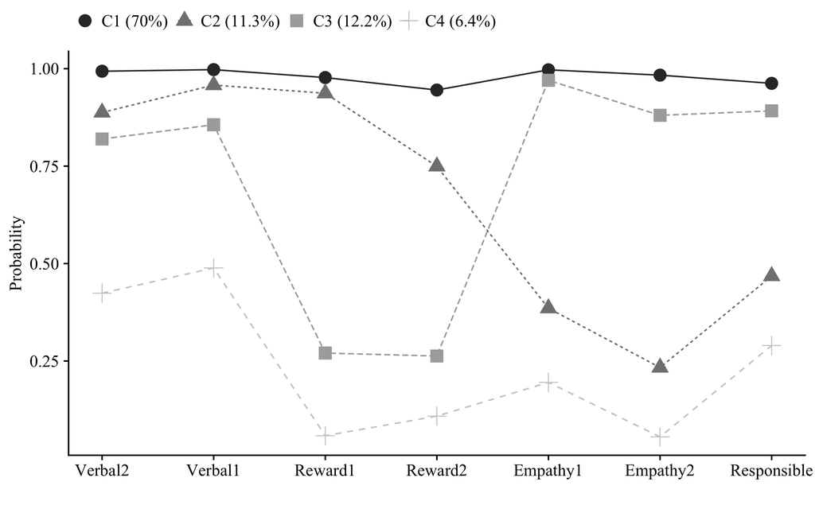

```r
ggsave(here("figures","C4_LCA_MLCA.png"), dpi=300, height=5, width=8, units="in")
```

## ______________________________________________

### model00: Compute intra-class correlations (type = basic; w/ analysis = TWOLEVEL;)

```r
# Note: In this example the ICC's are zero because items are dichotomous

  mlca_00  <- mplusObject(

    TITLE = "model00_basic__ICC_mlca",

    VARIABLE =
    "usevar = pos_1b-sel_1b;

     cluster = schlcode;
     within = pos_1b-sel_1b;",

  ANALYSIS =
   "estimator = mlr;
    type = basic twolevel; ! ask for ICC curves
    processors = 10;",

  MODEL = "",

  OUTPUT = "sampstat;",

  PLOT = "",

  usevariables = colnames(mlca_mplus),
  rdata = mlca_mplus)

mlca_00_fit <- mplusModeler(mlca_00,
                            dataout=here("mlca_mplus", "model00_basic.dat"),
                            modelout=here("mlca_mplus", "model00_basic.inp"),
                            check=TRUE, run = TRUE, hashfilename = FALSE)
```

## ______________________________________________

## Compare Multi-level parametric & non-parametric models described in Henry & Muthen (2010)

## ______________________________________________

### model01: parametric random effects model (4-class)

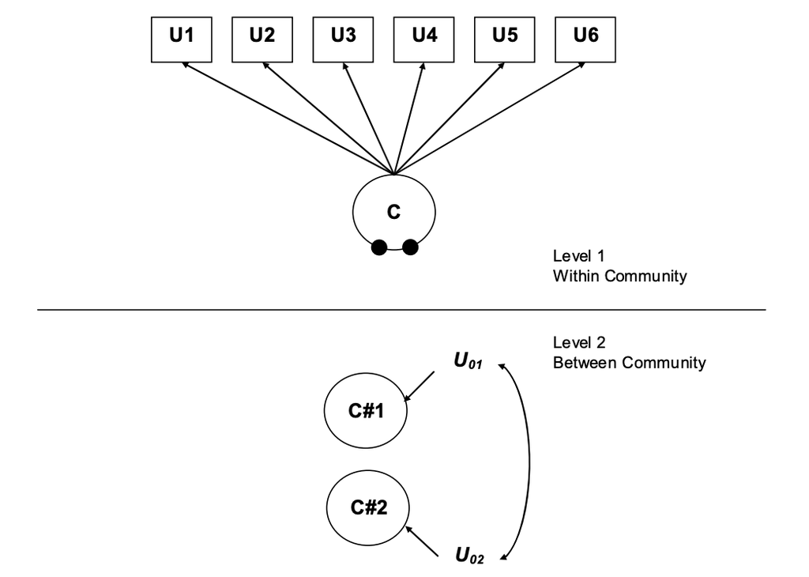

#### *Figure 1.* Picture adapted from, Henry & Muthen 2010

```r
# warning, run-time is very slow

  mlca_01  <- mplusObject(

    TITLE = "model01_parametric_mlca",

    VARIABLE =
    "usevar = pos_1b-sel_1b;
     categorical = pos_1b-sel_1b;
     classes = c(4);

     cluster = schlcode;      ! level 2 units are schools
     within = pos_1b-sel_1b;",

  ANALYSIS =
   "estimator = mlr;
    type = mixture twolevel;
    integration=montecarlo(1000);
    starts = 100 50;
    processors = 10;",

  MODEL =
    "%WITHIN%
     %OVERALL%

     %BETWEEN%
     %OVERALL%
     C#1;
     C#2;
     C#3;
     C#1 WITH C#2;
     C#3 WITH C#1 C#2; ",

  OUTPUT = "TECH8;",

  PLOT =
    "type = plot3;
    series = pos_1b-sel_1b(*);",

  usevariables = colnames(mlca_mplus),
  rdata = mlca_mplus)

mlca_01_fit <- mplusModeler(mlca_01,
                            dataout=here("mlca_mplus", "model01_parametric.dat"),
                            modelout=here("mlca_mplus", "model01_parametric.inp"),
                            check=TRUE, run = FALSE, hashfilename = FALSE)
```

## ______________________________________________

### model02: parametric model with 2nd level factor

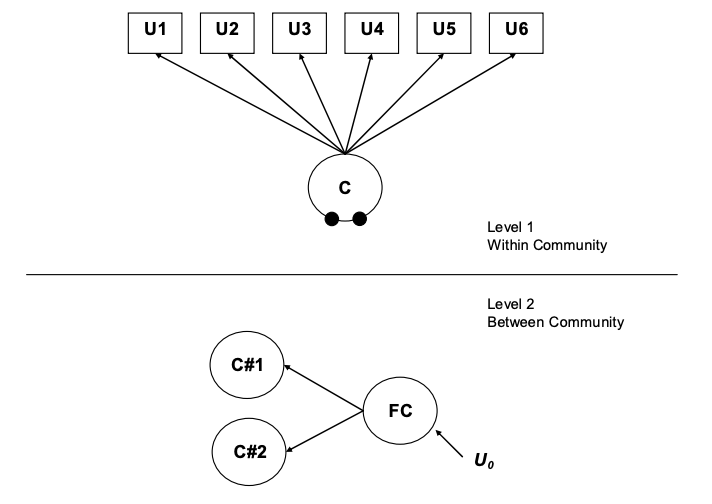

#### *Figure 2.* Picture adapted from, Henry & Muthen 2010

```r
  mlca_02  <- mplusObject(

    TITLE = "model02_parametric_mlca",

    VARIABLE =
    "usevar = pos_1b-sel_1b;
     categorical = pos_1b-sel_1b;
     classes = c(4);

     cluster = schlcode;      ! level 2 units are schools
     within = pos_1b-sel_1b;",

  ANALYSIS =
   "estimator = mlr;
    type = mixture twolevel;
    starts = 20 10;
    processors = 10;",

  MODEL =
    "%WITHIN%
     %OVERALL%

     %BETWEEN%
     %OVERALL%
     FC by C#1 C#2 C#3;",

  OUTPUT = "TECH8;",

  PLOT =
    "type = plot3;
    series = pos_1b-sel_1b(*);",

  usevariables = colnames(mlca_mplus),
  rdata = mlca_mplus)

mlca_02_fit <- mplusModeler(mlca_02,
                            dataout=here("mlca_mplus", "model02_parametric.dat"),
                            modelout=here("mlca_mplus", "model02_parametric.inp"),
                            check=TRUE, run = FALSE, hashfilename = FALSE)
```

## ______________________________________________

### model03: non-parametric model

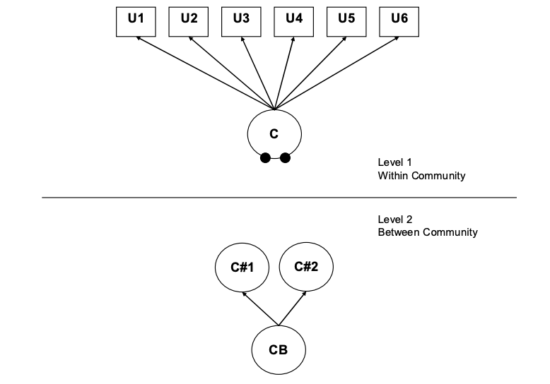

#### *Figure 3.* Picture adapted from, Henry & Muthen 2010

```r
  mlca_03  <- mplusObject(

    TITLE = "model03_non_parametric_mlca",

    VARIABLE =
    "usevar = pos_1b-sel_1b;
     categorical = pos_1b-sel_1b;
     classes = CB(3) c(4);

     cluster = schlcode;      ! level 2 units are schools
     within = pos_1b-sel_1b;
     between = CB;",

  ANALYSIS =
   "estimator = mlr;
    type = mixture twolevel;
    starts = 20 10;
    processors = 10;",

  MODEL =
    "%WITHIN%
     %OVERALL%

     %BETWEEN%
     %OVERALL%
     C on CB;

     MODEL C:
     %WITHIN%
     %C#1%
     [pos_1b$1-sel_1b$1];
     %C#2%
     [pos_1b$1-sel_1b$1];
     %C#3%
     [pos_1b$1-sel_1b$1];
     %C#4%
     [pos_1b$1-sel_1b$1]; ",

  OUTPUT = "TECH8;",

  PLOT =
    "type = plot3;
    series = pos_1b-sel_1b(*);",

  usevariables = colnames(mlca_mplus),
  rdata = mlca_mplus)

mlca_03_fit <- mplusModeler(mlca_03,
                            dataout=here("mlca_mplus", "model03_non_parametric.dat"),
                            modelout=here("mlca_mplus", "model03_non_parametric.inp"),
                            check=TRUE, run = FALSE, hashfilename = FALSE)
```

## ______________________________________________

### model04: parametric model with 2nd level factor on random latent class indicators

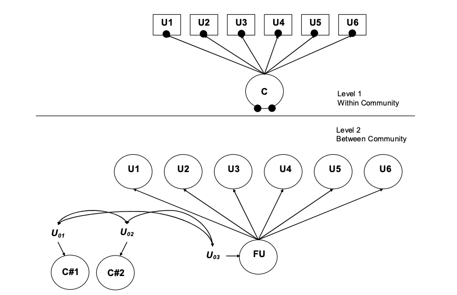

#### *Figure 4.* Picture adapted from, Henry & Muthen 2010

```r
  mlca_04  <- mplusObject(

    TITLE = "model04_parametric_mlca",

    VARIABLE =
    "usevar = pos_1b-sel_1b;
     categorical = pos_1b-sel_1b;
     classes = c(4);

     cluster = schlcode; ",

  ANALYSIS =
   "estimator = mlr;
    type = mixture twolevel;
    starts = 20 10;
    processors = 10;",

  MODEL =
    "%WITHIN%
     %OVERALL%

     %BETWEEN%
     %OVERALL%
     FU by pos_1b-sel_1b;
     [FU@0];
     FU WITH C#1 C#2 C#3;
     C#1;
     C#2;
     C#3;
     C#1 WITH C#2;
     C#3 WITH C#1 C#2;

     %C#1%
     [pos_1b$1-sel_1b$1];
     %C#2%
     [pos_1b$1-sel_1b$1];
     %C#3%
     [pos_1b$1-sel_1b$1];
     %C#4%
     [pos_1b$1-sel_1b$1]; ",

  OUTPUT = "TECH8;",

  PLOT =
    "type = plot3;
    series = pos_1b-sel_1b(*);",

  usevariables = colnames(mlca_mplus),
  rdata = mlca_mplus)

mlca_04_fit <- mplusModeler(mlca_04,
                            dataout=here("mlca_mplus", "model04_parametric.dat"),
                            modelout=here("mlca_mplus", "model04_parametric.inp"),
                            check=TRUE, run = F, hashfilename = FALSE)
```

## ______________________________________________

### model05: parametric model with 2nd level factor on random latent class intercepts & 2nd level factor on random latent class indicators

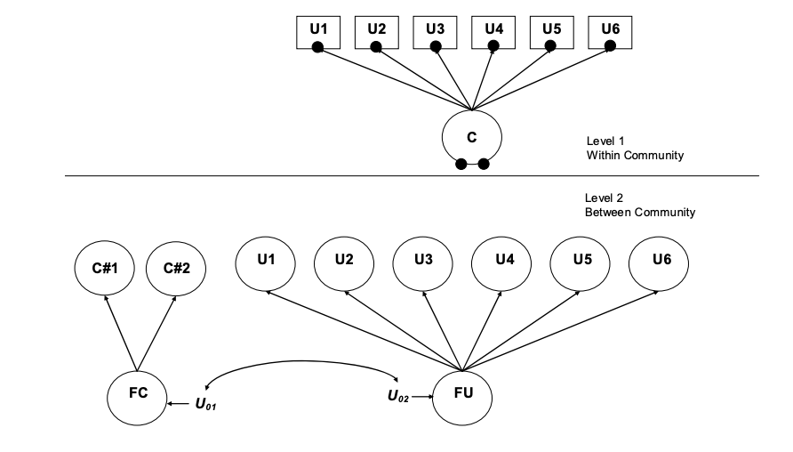

#### *Figure 5.* Picture adapted from, Henry & Muthen 2010

```r
  mlca_05  <- mplusObject(

    TITLE = "model05_parametric_mlca",

    VARIABLE =
    "usevar = pos_1b-sel_1b;
     categorical = pos_1b-sel_1b;
     classes = c(4);

     cluster = schlcode; ",

  ANALYSIS =
   "estimator = mlr;
    type = mixture twolevel;
    starts = 20 10;
    processors = 10;",

  MODEL =
    "%WITHIN%
     %OVERALL%

     %BETWEEN%
     %OVERALL%
     FU by pos_1b-sel_1b;
     [FU@0];
     FC BY C#1 C#2 C#3;
     FC WITH FU;

     %C#1%
     [pos_1b$1-sel_1b$1];
     %C#2%
     [pos_1b$1-sel_1b$1];
     %C#3%
     [pos_1b$1-sel_1b$1];
     %C#4%
     [pos_1b$1-sel_1b$1]; ",

  OUTPUT = "TECH8;",

  PLOT =
    "type = plot3;
    series = pos_1b-sel_1b(*);",

  usevariables = colnames(mlca_mplus),
  rdata = mlca_mplus)

mlca_05_fit <- mplusModeler(mlca_05,
                            dataout=here("mlca_mplus", "model05_parametric.dat"),
                            modelout=here("mlca_mplus", "model05_parametric.inp"),
                            check=TRUE, run = F, hashfilename = FALSE)
```

## ______________________________________________

### model06: non-parametric model with level-2 factor on latent class indicators

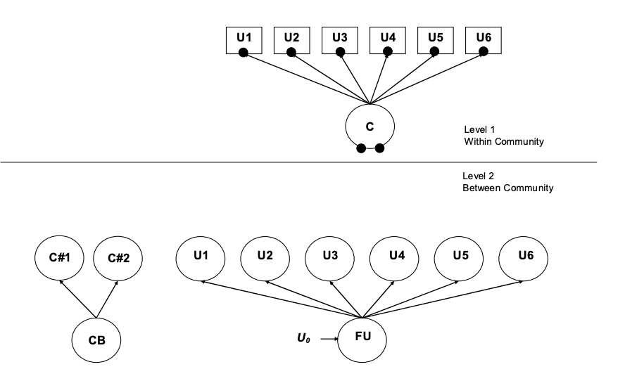

```r
  mlca_06  <- mplusObject(

    TITLE = "model06_non_parametric_mlca",

    VARIABLE =
    "usevar = pos_1b-sel_1b;
     categorical = pos_1b-sel_1b;
     classes = CB(2) c(4);

     cluster = schlcode;      ! level 2 units are schools
     between = CB;",

  ANALYSIS =
   "estimator = mlr;
    type = mixture twolevel;
    starts = 20 10;
    processors = 10;",

  MODEL =
    "%WITHIN%
     %OVERALL%

     %BETWEEN%
     %OVERALL%
     FU BY pos_1b-sel_1b;
     [FU@0];
     C on CB;

     MODEL CB:
     %BETWEEN%
     %CB#1%
     [FU@0];
     %CB#2%
     [FU];

     MODEL C:
     %BETWEEN%
     %C#1%
     [pos_1b$1-sel_1b$1];
     %C#2%
     [pos_1b$1-sel_1b$1];
     %C#3%
     [pos_1b$1-sel_1b$1];
     %C#4%
     [pos_1b$1-sel_1b$1]; ",

  OUTPUT = "TECH8;",

  PLOT =
    "type = plot3;
    series = pos_1b-sel_1b(*);",

  usevariables = colnames(mlca_mplus),
  rdata = mlca_mplus)

mlca_06_fit <- mplusModeler(mlca_06,
                            dataout=here("mlca_mplus", "model06_non_parametric.dat"),
                            modelout=here("mlca_mplus", "model06_non_parametric.inp"),
                            check=TRUE, run = FALSE, hashfilename = FALSE)
```

## ______________________________________________

### model07: parametric model with 2nd level factor on random latent class intercepts & 2nd level factor on random latent class indicators

#### Auxiliaries: one individual-level covariate & two school-level covariates

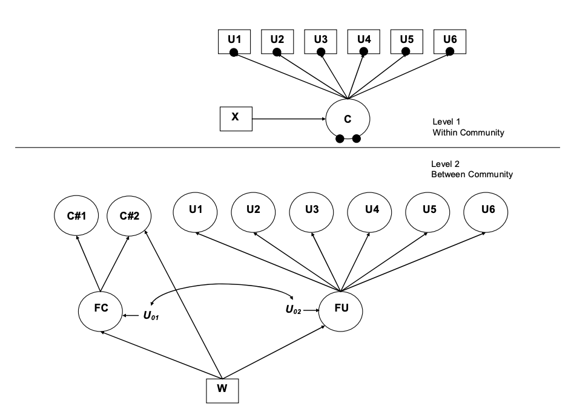

#### *Figure 7.* Picture adapted from, Henry & Muthen 2010

#### school-level covariates

```r
# table(mlca_mplus$level)    # 2836 elementary school students
# table(mlca_mplus$d_middle) # 1174 middle school students
# table(mlca_mplus$d_high)   # 1084 high-school students
```

```r
  mlca_07  <- mplusObject(

    TITLE = "model07_parametric_mlca",

    VARIABLE =
    "usevar = pos_1b-sel_1b d_middle d_high d_female;
     categorical = pos_1b-sel_1b;
     classes = c(4);

     cluster = schlcode;
     between = d_middle d_high;
      within = d_female;
    ",

  ANALYSIS =
   "estimator = mlr;
    algorithm = integration;
    type = mixture twolevel;
    starts = 20 10;
    processors = 10;",

  MODEL =
    "%WITHIN%
     %OVERALL%
     C#1-C#3 on d_female;

     %BETWEEN%
     %OVERALL%
     FU BY pos_1b@1;
     FU BY pos_3b (F_pos_3b);
     FU BY pos_2b (F_pos_2b);
     FU BY pos_4b (F_pos_4b);
     FU BY sel_5b (F_sel_5b);
     FU BY sel_2b (F_sel_2b);
     FU BY sel_1b (F_sel_1b);

     [FU@0];
     FC BY C#1 (FC_C1);
     FC BY C#2 (FC_C2);
     FC BY C#3 (FC_C3);
     FU WITH FC;

     C#2 ON d_middle (C2_mid);
     C#2 ON d_high   (C2_hs);

     FC ON d_middle (FC_mid);
     FC ON d_high   (FC_hs);
     FU ON d_middle (FU_mid);
     FU ON d_high   (FU_hs);

     %C#1%
     [pos_1b$1-sel_1b$1];
     %C#2%
     [pos_1b$1-sel_1b$1];
     %C#3%
     [pos_1b$1-sel_1b$1];
     %C#4%
     [pos_1b$1-sel_1b$1]; ",

  MODELCONSTRAINT =
    "NEW(MID_EV MID_pos3 MID_pos2 MID_pos4 MID_sel5 MID_sel2 MID_sel1
     HS_EV HS_pos3 HS_pos2 HS_pos4 HS_sel5 HS_sel2 HS_sel1
     C2_MIDSC C2_HIGHS);

       MID_EV = FU_mid;
     MID_pos3 = FU_mid*F_pos_3b;
     MID_pos2 = FU_mid*F_pos_2b;
     MID_pos4 = FU_mid*F_pos_4b;
     MID_sel5 = FU_mid*F_sel_5b;
     MID_sel2 = FU_mid*F_sel_2b;
     MID_sel1 = FU_mid*F_sel_1b;

       HS_EV = FU_hs;
     HS_pos3 = FU_hs*F_pos_3b;
     HS_pos2 = FU_hs*F_pos_2b;
     HS_pos4 = FU_hs*F_pos_4b;
     HS_sel5 = FU_hs*F_sel_5b;
     HS_sel2 = FU_hs*F_sel_2b;
     HS_sel1 = FU_hs*F_sel_1b;

     C2_MIDSC = (FC_mid*FC_C2)+C2_mid;
     C2_HIGHS = (FC_hs*FC_C2)+C2_hs;",

  OUTPUT = "TECH8;",

  PLOT =
    "type = plot3;
    series = pos_1b-sel_1b(*);",

  usevariables = colnames(mlca_mplus),
  rdata = mlca_mplus)

mlca_07_fit <- mplusModeler(mlca_07,
                            dataout=here("mlca_mplus", "model07_parametric.dat"),
                            modelout=here("mlca_mplus", "model07_parametric.inp"),
                            check=TRUE, run = F, hashfilename = FALSE)
```

## ______________________________________________

#### Table of model fit

```r
output_mlca <- readModels(here("mlca_out"))
```

```
## Reading model:  /Users/agarber/github/project-site/mlca_out/model01_par_L2_3D.out
## Reading model:  /Users/agarber/github/project-site/mlca_out/model02_par_L2_3D.out
## Reading model:  /Users/agarber/github/project-site/mlca_out/model03_non_par.out
## Reading model:  /Users/agarber/github/project-site/mlca_out/model05_par.out
## Reading model:  /Users/agarber/github/project-site/mlca_out/model06_non_par.out
## Reading model:  /Users/agarber/github/project-site/mlca_out/model07_par_final.out
```

```r
mlca_summary <- LatexSummaryTable(output_mlca,
                keepCols=c("Title",
                           "Parameters",
                           "LL",
                           "BIC",
                           "aBIC"),
                                   sortBy = "Title")

mlca_summary %>%
  kable(booktabs = T, linesep = "") %>%
  kable_styling(c("striped"),
                full_width = F,
                position = "left")
```

| Title | Parameters | LL | BIC | aBIC |
| --- | --- | --- | --- | --- |
| model01_parametric_mlca | 37 | -9928.028 | 20171.83 | 20054.26 |
| model02_parametric_mlca | 34 | -10025.484 | 20341.14 | 20233.10 |
| model03_non_parametric_mlca | 39 | -10018.788 | 20370.42 | 20246.49 |
| model05_parametric_mlca | 42 | -9832.084 | 20022.62 | 19889.15 |
| model06_non_parametric_mlca | 43 | -9847.624 | 20062.23 | 19925.59 |
| model07_parametric_mlca | 51 | -9768.308 | 19971.87 | 19809.81 |

#### create a path diagram of the final model

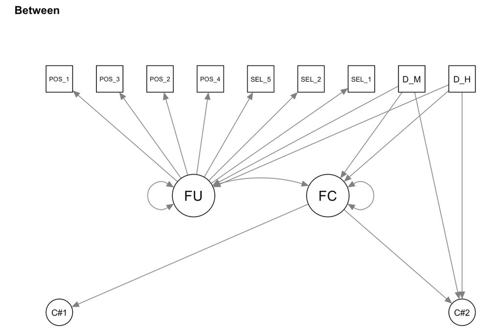

```r
# Read in the model to R
final_model <- readModels(here("mlca_out", "model07_par_covs.out"))

# Plot model:
semPaths(final_model,
         intercepts=FALSE,
         fixedStyle = c(1))
```

## ______________________________________________

## ______________________________________________